# Project Week 1

### Double Exponential Smoothing

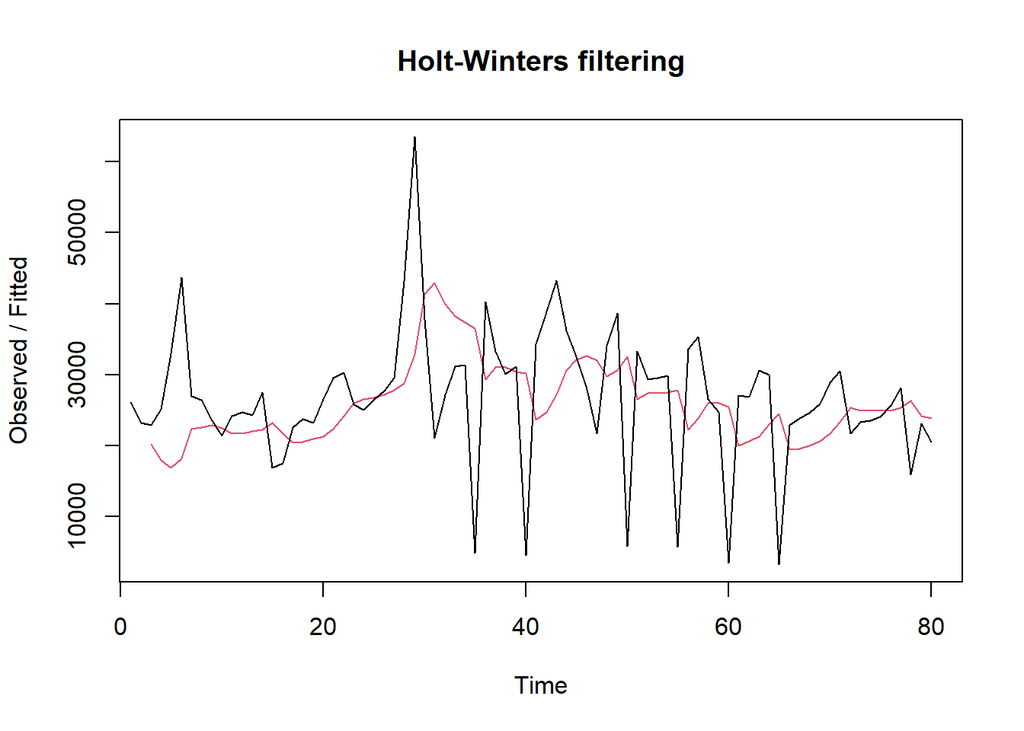

```r
#Lamda=0.2 dan gamma=0.2
des.1<- HoltWinters(traints2, gamma = FALSE, beta = 0.2, alpha = 0.2)
plot(des.1)
```

```r
#ramalan
ramalandes1<- forecast(des.1, h=20)
ramalandes1
```

```
##     Point Forecast       Lo 80    Hi 80       Lo 95    Hi 95
##  81       23003.12   9389.8375 36616.41   2183.3989 43822.85
##  82       22779.53   8779.6647 36779.39   1368.5863 44190.46
##  83       22555.93   8046.4361 37065.42    365.5761 44746.28
##  84       22332.33   7182.9963 37481.66   -836.5751 45501.23
##  85       22108.73   6186.4200 38031.04  -2242.3409 46459.80
##  86       21885.13   5057.4335 38712.83  -3850.6108 47620.87
##  87       21661.53   3799.5708 39523.49  -5655.9796 48979.04
##  88       21437.93   2418.2657 40457.60  -7650.1374 50526.00
##  89       21214.33    920.0319 41508.63  -9823.1220 52251.79
##  90       20990.73   -688.1842 42669.65 -12164.3103 54145.78
##  91       20767.14  -2399.4628 43933.73 -14663.1189 56197.39
##  92       20543.54  -4207.2005 45294.27 -17309.4492 58396.52
##  93       20319.94  -6105.2715 46745.15 -20093.9321 60733.81
##  94       20096.34  -8088.0963 48280.77 -23008.0349 63200.71
##  95       19872.74 -10150.6530 49896.13 -26044.0770 65789.56
##  96       19649.14 -12288.4532 51586.73 -29195.1942 68493.48
##  97       19425.54 -14497.5005 53348.58 -32455.2744 71306.36
##  98       19201.94 -16774.2411 55178.13 -35818.8827 74222.77
##  99       18978.34 -19115.5137 57072.20 -39281.1839 77237.87
## 100       18754.75 -21518.5009 59027.99 -42837.8697 80347.36
```

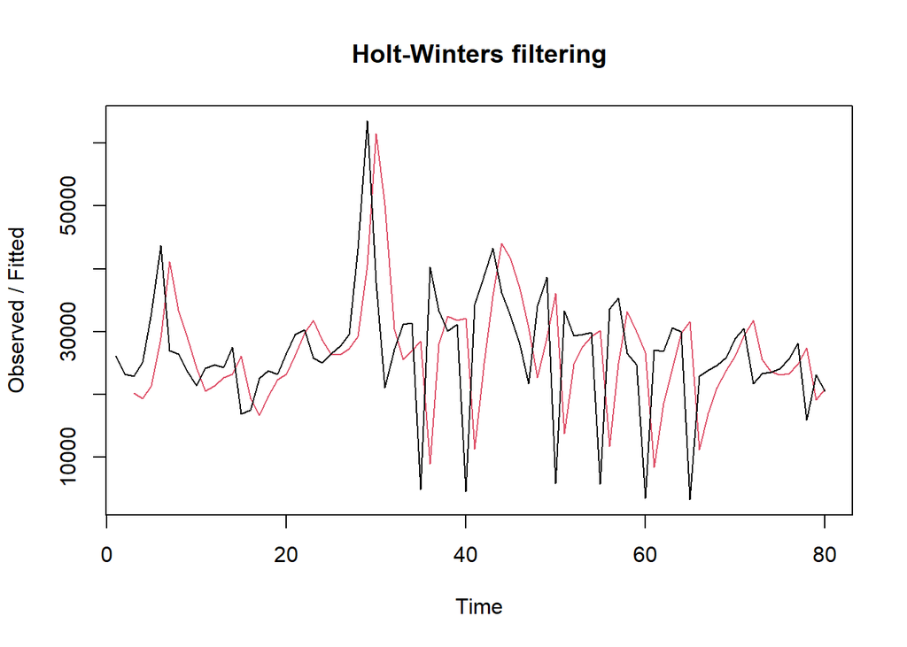

```r
#Lamda=0.6 dan gamma=0.3
des.2<- HoltWinters(traints2, gamma = FALSE, beta = 0.3, alpha = 0.6)
plot(des.2)
```

```r
#ramalan
ramalandes2<- forecast(des.2, h=20)
ramalandes2
```

```
##     Point Forecast        Lo 80     Hi 80       Lo 95     Hi 95
##  81      19958.856    4223.8595  35693.85   -4105.744  44023.46
##  82      19219.697    -735.8516  39175.25  -11299.681  49739.07
##  83      18480.538   -6547.5051  43508.58  -19796.551  56757.63
##  84      17741.379  -13051.0066  48533.77  -29351.511  64834.27
##  85      17002.221  -20140.3697  54144.81  -39802.469  73806.91
##  86      16263.062  -27744.3208  60270.45  -51040.422  83566.55
##  87      15523.903  -35812.7116  66860.52  -62988.674  94036.48
##  88      14784.745  -44308.4930  73877.98  -75590.563 105160.05
##  89      14045.586  -53203.0697  81294.24  -88802.358 116893.53
##  90      13306.427  -62473.5485  89086.40 -102589.044 129201.90
##  91      12567.269  -72101.0471  97235.58 -116921.746 142056.28
##  92      11828.110  -82069.6132 105725.83 -131776.065 155432.29
##  93      11088.951  -92365.5061 114543.41 -147130.988 169308.89
##  94      10349.793 -102976.7027 123676.29 -162968.125 183667.71
##  95       9610.634 -113892.5465 133113.81 -179271.181 198492.45
##  96       8871.475 -125103.4916 142846.44 -196025.555 213768.51
##  97       8132.317 -136600.9100 152865.54 -213218.052 229482.69
##  98       7393.158 -148376.9445 163163.26 -230836.656 245622.97
##  99       6653.999 -160424.3936 173732.39 -248870.352 262178.35
## 100       5914.841 -172736.6201 184566.30 -267308.991 279138.67
```

Membandingkan plot data latih dan data uji.

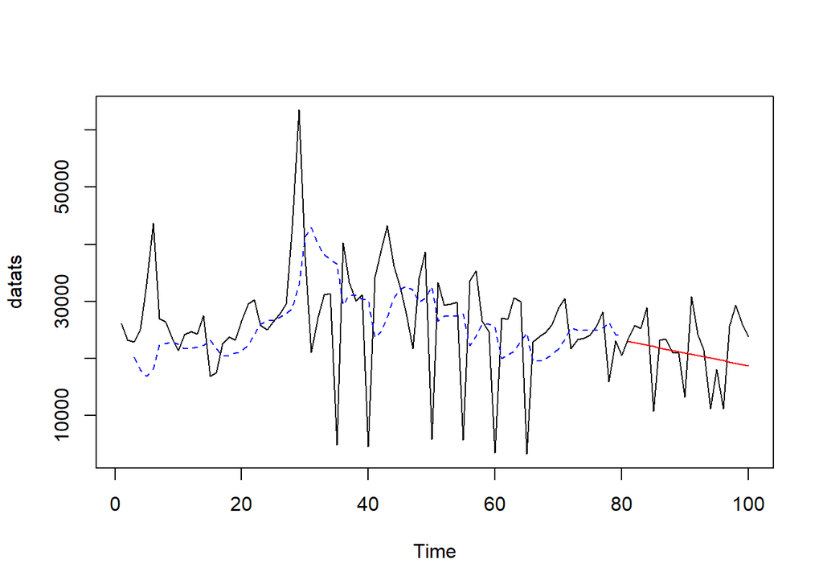

```r
#Visually evaluate the prediction
plot(datats)
lines(des.1$fitted[,1], lty=2, col="blue")
lines(ramalandes1$mean, col="red")
```

Mencari nilai parameter optimum

```r
#Lamda dan gamma optimum
des.opt<- HoltWinters(traints2, gamma = FALSE)
des.opt
```

```
## Holt-Winters exponential smoothing with trend and without seasonal component.
##
## Call:
## HoltWinters(x = traints2, gamma = FALSE)
##
## Smoothing parameters:
##  alpha: 0.1955582
##  beta : 0.1703259
##  gamma: FALSE
##
## Coefficients:
##         [,1]
## a 23154.3443
## b  -153.1015
```

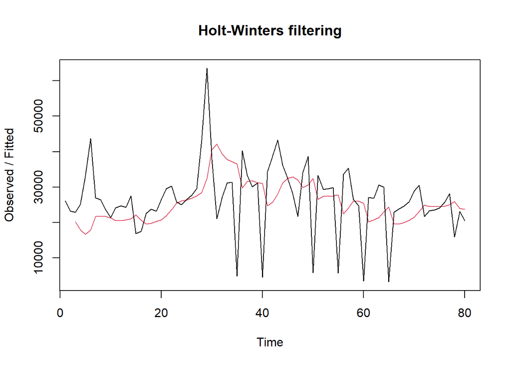

```r
plot(des.opt)
```

```r
#ramalan
ramalandesopt<- forecast(des.opt, h=20)
ramalandesopt
```

```
##     Point Forecast        Lo 80    Hi 80       Lo 95    Hi 95
##  81       23001.24   9440.79259 36561.69   2262.3239 43740.16
##  82       22848.14   8937.07542 36759.21   1573.0020 44123.28
##  83       22695.04   8336.86008 37053.22    736.0988 44653.98
##  84       22541.94   7635.14278 37448.73   -256.0381 45339.91
##  85       22388.84   6829.54804 37948.13  -1407.0420 46184.72
##  86       22235.74   5920.03435 38551.44  -2716.9761 47188.45
##  87       22082.63   4908.45335 39256.81  -4183.0087 48348.28
##  88       21929.53   3798.05065 40061.01  -5800.1761 49659.24
##  89       21776.43   2592.98520 40959.88  -7562.1176 51114.98
##  90       21623.33   1297.91716 41948.74  -9461.7062 52708.37
##  91       21470.23    -82.31352 43022.77 -11491.5399 54432.00
##  92       21317.13  -1542.91726 44177.17 -13644.2935 56278.55
##  93       21164.03  -3079.30563 45407.36 -15912.9497 58241.00
##  94       21010.92  -4687.17981 46709.03 -18290.9341 60312.78
##  95       20857.82  -6362.57352 48078.22 -20772.1806 62487.83
##  96       20704.72  -8101.86494 49511.31 -23351.1503 64760.59
##  97       20551.62  -9901.76900 51005.01 -26022.8190 67126.06
##  98       20398.52 -11759.31811 52556.35 -28782.6482 69579.68
##  99       20245.42 -13671.83691 54162.67 -31626.5462 72117.38
## 100       20092.31 -15636.91488 55821.54 -34550.8266 74735.46
```

#### Akurasi Data Latih

```r
#Akurasi Data Training
ssedes.train1<-des.1$SSE
msedes.train1<-ssedes.train1/length(traints2)
sisaandes1<-ramalandes1$residuals
head(sisaandes1)
```

```
## Time Series:
## Start = 1
## End = 6
## Frequency = 1
## [1]       NA       NA  2612.00  7236.12 16105.97 25551.61
```

```r
mapedes.train1 <- sum(abs(sisaandes1[3:length(traints2)]/traints2[3:length(traints2)])
                      *100)/length(traints2)

akurasides.1 <- matrix(c(ssedes.train1,msedes.train1,mapedes.train1))
row.names(akurasides.1)<- c("SSE", "MSE", "MAPE")
colnames(akurasides.1) <- c("Akurasi lamda=0.2 dan gamma=0.2")
akurasides.1
```

```
##      Akurasi lamda=0.2 dan gamma=0.2
## SSE                     8.747489e+09
## MSE                     1.093436e+08
## MAPE                    5.929683e+01
```

```r
ssedes.train2<-des.2$SSE
msedes.train2<-ssedes.train2/length(traints2)
sisaandes2<-ramalandes2$residuals
head(sisaandes2)
```

```
## Time Series:
## Start = 1
## End = 6
## Frequency = 1
## [1]       NA       NA  2612.00  5825.64 11522.48 14721.17
```

```r
mapedes.train2 <- sum(abs(sisaandes2[3:length(traints2)]/traints2[3:length(traints2)])
                      *100)/length(traints2)

akurasides.2 <- matrix(c(ssedes.train2,msedes.train2,mapedes.train2))
row.names(akurasides.2)<- c("SSE", "MSE", "MAPE")
colnames(akurasides.2) <- c("Akurasi lamda=0.6 dan gamma=0.3")
akurasides.2
```

```
##      Akurasi lamda=0.6 dan gamma=0.3
## SSE                     1.160976e+10
## MSE                     1.451220e+08
## MAPE                    6.691419e+01
```

Dengan menggunakan lambda = 0.2 dan gamma = 0.2, didapat nilai MAPE yang lebih kecil, artinya parameter lambda dan gamma = 0.2 memberikan hasil yang lebih baik daripada lambda = 0.6 dan gamma = 0.3

#### Akurasi Data Uji

```r
#Akurasi Data Testing
selisihdes1<-ramalandes1$mean-test2$Jumlah
selisihdes1
```

```
## Time Series:
## Start = 81
## End = 100
## Frequency = 1
##  [1]   -385.8761  -3001.4749  -2709.0738  -6631.6727  11338.7284  -1321.8704
##  [7]  -1749.4693    399.9318    224.3329   7692.7341 -10074.8648  -3709.4637
## [13]  -1212.0626   8885.3386   1808.7397   8441.1408  -6283.4581 -10137.0569
## [19]  -7064.6558  -5113.2547
```

```r
SSEtestingdes1<-sum(selisihdes1^2)
MSEtestingdes1<-SSEtestingdes1/length(test2$Jumlah)
MAPEtestingdes1<-sum(abs(selisihdes1/test2$Jumlah)*100)/length(test2$Jumlah)

selisihdes2<-ramalandes2$mean-test2$Jumlah
selisihdes2
```

```
## Time Series:
## Start = 81
## End = 100
## Frequency = 1
##  [1]  -3430.144482  -6561.303161  -6784.461841 -11222.620520   6232.220800
##  [6]  -6943.937879  -7887.096559  -6253.255238  -6944.413918      8.427403
## [11] -18274.731276 -12424.889956 -10443.048635   -861.207315  -8453.365994
## [16]  -2336.524674 -17576.683353 -21945.842033 -19389.000712 -17953.159391
```

```r
SSEtestingdes2<-sum(selisihdes2^2)
MSEtestingdes2<-SSEtestingdes2/length(test2$Jumlah)
MAPEtestingdes2<-sum(abs(selisihdes2/test2$Jumlah)*100)/length(test2$Jumlah)

selisihdesopt<-ramalandesopt$mean-test2$Jumlah
selisihdesopt
```

```
## Time Series:
## Start = 81
## End = 100
## Frequency = 1
##  [1]  -387.7572 -2932.8587 -2569.9601 -6422.0616 11618.8369  -971.2645
##  [7] -1328.3660   891.5325   786.4311  8325.3296 -9371.7719 -2935.8734
## [13]  -367.9748  9799.9237  2793.8222  9496.7208 -5157.3807 -8940.4822
## [19] -5797.5836 -3775.6851
```

```r
SSEtestingdesopt<-sum(selisihdesopt^2)
MSEtestingdesopt<-SSEtestingdesopt/length(test2$Jumlah)
MAPEtestingdesopt<-sum(abs(selisihdesopt/test2$Jumlah)*100)/length(test2$Jumlah)

akurasitestingdes <-
  matrix(c(SSEtestingdes1,MSEtestingdes1,MAPEtestingdes1,SSEtestingdes2,MSEtestingdes2,
           MAPEtestingdes2,SSEtestingdesopt,MSEtestingdesopt,MAPEtestingdesopt),
         nrow=3,ncol=3)
row.names(akurasitestingdes)<- c("SSE", "MSE", "MAPE")
colnames(akurasitestingdes) <- c("des ske1","des ske2","des opt")
akurasitestingdes
```

```
##          des ske1     des ske2      des opt
## SSE  7.417414e+08 2.627256e+09 7.100444e+08
## MSE  3.708707e+07 1.313628e+08 3.550222e+07
## MAPE 2.759466e+01 4.086055e+01 2.770679e+01
```

#### Perbandingan SES dengan DES

```r
MSEfull <-
  matrix(c(MSEtesting1,MSEtesting2,MSEtestingopt,MSEtestingdes1,MSEtestingdes2,
           MSEtestingdesopt),nrow=3,ncol=2)
row.names(MSEfull)<- c("ske 1", "ske 2", "ske opt")
colnames(MSEfull) <- c("SES","DES")
MSEfull
```

```
##               SES       DES
## ske 1   239455310  37087068
## ske 2   239332074 131362823
## ske opt 353589866  35502219
```

Berdasarkan nilai akurasi MSE, metode DES lebih baik dibandingkan metode SES. Hal ini dikarenakan nilai MES pada metode DES lebih kecil dibandingkan metode SES.

#### Akurasi DES

```r
accuracy(ramalandesopt,test2$Jumlah)
```

```
##                     ME      RMSE      MAE        MPE     MAPE      MASE
## Training set 1071.5242 10567.693 7371.936 -35.466737 60.87888 0.9372216
## Test set      362.3212  5958.374 4733.581  -8.901525 27.70679 0.6017977
##                   ACF1
## Training set 0.1260325
## Test set            NA
```

### Pemulusan Data Musiman

```r
datats3<-ts(dataa$Jumlah)
```

### Pembagian data latih dan data uji

```r
train3<-dataa[1:80,2]
uji3<-dataa[81:100,2]
traints3<-ts(train3,frequency = 5)
ujits3<-ts(uji3,frequency = 5)
```

### Eksplorasi data

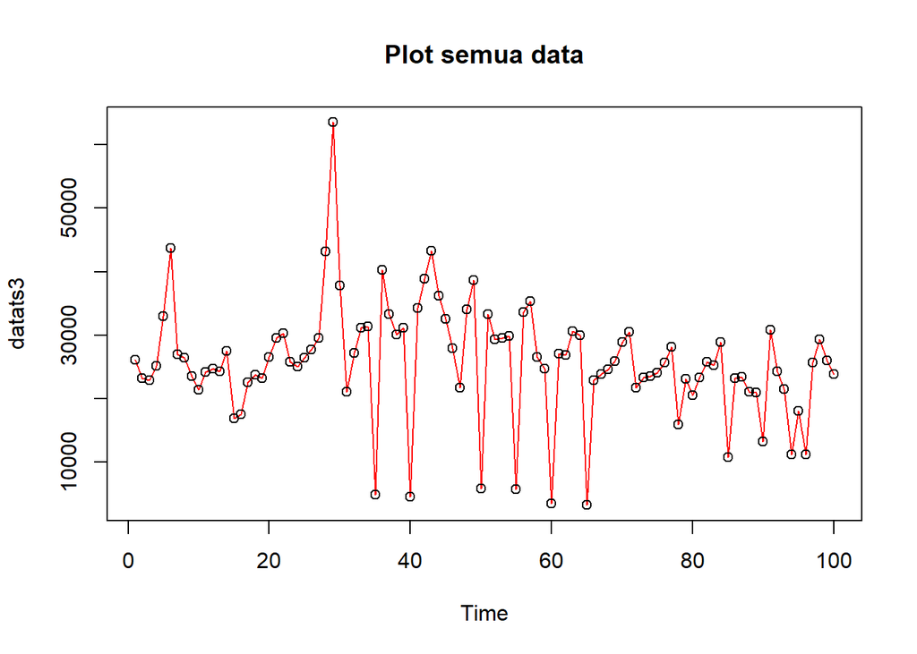

```r
plot(datats3, col="red",main="Plot semua data")
points(datats3)
```

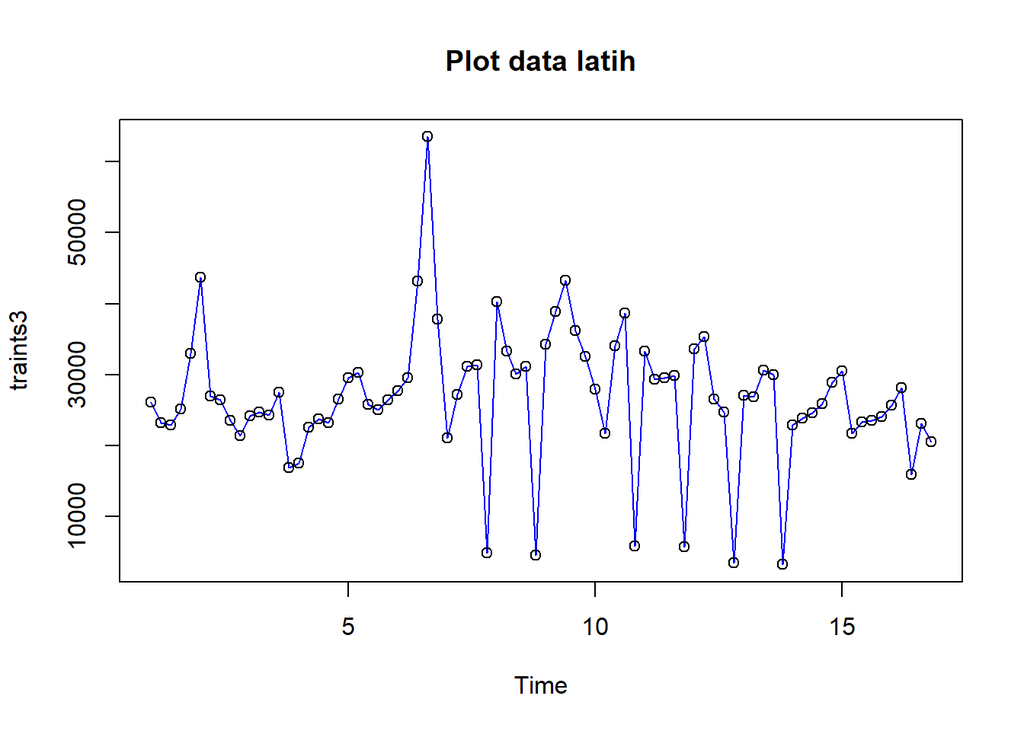

```r
plot(traints3, col="blue",main="Plot data latih")
points(traints3)
```

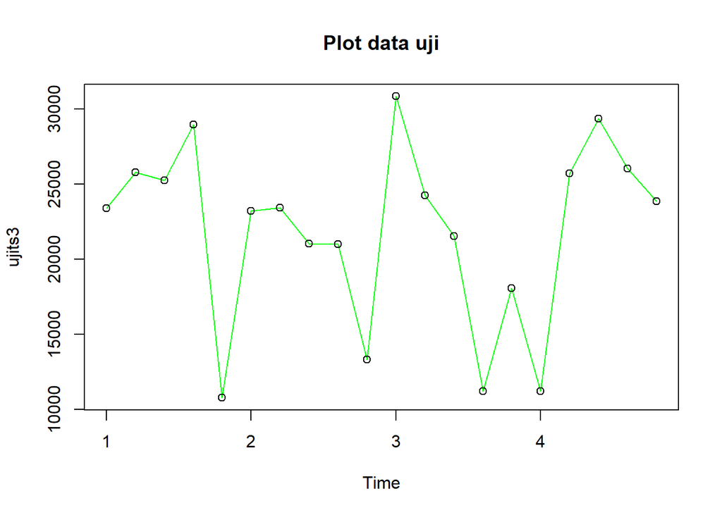

```r
plot(ujits3, col="green",main="Plot data uji")
points(ujits3)
```

### Winter Aditif

#### Pemulusan

```r
winter1 <- HoltWinters(traints3,alpha=0.2,beta=0.1,gamma=0.1,seasonal = "additive")
winter1$fitted
```

```
## Time Series:
## Start = c(2, 1)
## End = c(16, 5)
## Frequency = 5
##          xhat    level       trend       season
##  2.0 39999.87 27786.85  455.137143 11757.880000
##  2.2 24841.98 28989.42  529.879733 -4677.320000
##  2.4 27038.38 29946.50  572.600211 -3480.720000
##  2.6 25659.36 30407.62  561.452589 -5309.720000
##  2.8 32782.07 30552.41  519.785440  1709.880000
##  3.0 41140.37 28791.78  291.744011 12056.850362
##  3.2 21137.11 25691.05  -47.503419 -4506.438089
##  3.4 22856.11 26357.52   23.894474 -3525.310488
##  3.6 21255.82 26678.60   53.612348 -5476.388598
##  3.8 28952.85 27977.04  178.095961   797.714287
##  4.0 36394.45 25756.37  -61.781125 10699.860641
##  4.2 17277.62 21936.10 -437.630098 -4220.846516
##  4.4 18831.70 22568.74 -330.602532 -3406.438996
##  4.6 18021.23 23231.00 -231.316578 -4978.454143
##  4.8 23763.06 24051.04 -126.181181  -161.794057
##  5.0 33611.13 24484.84  -70.182441  9196.464748
##  5.2 19665.12 23608.64 -150.784977 -3792.736250
##  5.4 22638.55 25585.83   62.012714 -3009.295182
##  5.6 21841.30 26274.53  124.681791 -4557.912554
##  5.8 27282.33 27032.15  187.975765    62.200902
##  6.0 36094.65 27049.66  170.929159  8874.054606
##  6.2 22616.13 25553.46    4.216217 -2941.545486
##  6.4 24319.93 26936.45  142.093541 -2758.618873
##  6.6 27052.14 30838.76  518.114997 -4304.736660
##  6.8 39883.79 38643.05 1246.732218    -5.985521
##  7.0 48876.92 39465.42 1204.296328  8207.202839
##  7.2 33380.76 35121.33  649.457921 -2390.036190
##  7.4 33795.61 34525.24  524.902819 -1254.533049
##  7.6 33598.12 34516.82  471.570617 -1390.267778
##  7.8 34797.57 34545.97  427.328138  -175.729083
##  8.0 34803.75 28987.18 -171.283182  5987.849214
##  8.2 26967.95 29917.35  -61.138140 -2888.256601
##  8.4 29726.64 31128.42   66.082773 -1467.861855
##  8.6 29769.33 31263.57   72.989952 -1567.237693
##  8.8 29157.65 31625.90  101.923414 -2570.174363
```

[output cut: 25 more lines]

```
## 14.0 27555.77 22389.15 -420.641552  5587.262038
## 14.2 20271.82 21046.76 -512.817015  -262.114802
## 14.4 21561.29 21247.97 -441.413509   754.732745
## 14.6 21193.29 21427.70 -379.299385   144.889493
## 14.8 11988.79 22000.74 -284.065233 -9727.884253
## 15.0 30385.72 25111.72   55.438869  5218.560184
## 15.2 25273.22 25191.82   57.904484    23.499223
## 15.4 25521.85 24532.48  -13.819895  1003.189242
## 15.6 24539.44 24072.09  -58.476800   525.826102
## 15.8 15369.35 23817.32  -78.105526 -8369.867848
## 16.0 30801.48 25477.35   95.707484  5228.422644
## 16.2 24283.92 24553.56   -6.242069  -263.398291
## 16.4 26207.37 25312.53   70.279550   824.561621
## 16.6 23650.82 23337.74 -134.227945   447.311200
## 16.8 15289.77 23108.15 -143.764373 -7674.615811
```

```r
xhat1 <- winter1$fitted[,2]

winter1.opt<- HoltWinters(traints3, alpha= NULL,  beta = NULL, gamma = NULL, seasonal = "additive")
winter1.opt
```

```
## Holt-Winters exponential smoothing with trend and additive seasonal component.
##
## Call:
## HoltWinters(x = traints3, alpha = NULL, beta = NULL, gamma = NULL,     seasonal = "additive")
##
## Smoothing parameters:
##  alpha: 0.07511462
##  beta : 0.07011048
##  gamma: 0.3165856
##
## Coefficients:
##           [,1]
## a   29375.5675
## b    -101.6719
## s1  -3198.7136
## s2  -4406.2841
## s3  -7005.2449
## s4  -4244.6107
## s5 -12103.5040
```

```r
winter1.opt$fitted
```

```
## Time Series:
## Start = c(2, 1)
## End = c(16, 5)
## Frequency = 5
##           xhat    level       trend       season
##  2.0 39999.870 27786.85  455.137143  11757.88000
##  2.2 24320.202 28522.70  474.818069  -4677.32000
##  2.4 26205.256 29197.16  488.814891  -3480.72000
##  2.6 24887.235 29706.69  490.267047  -5309.72000
##  2.8 32291.704 30098.46  483.361660   1709.88000
##  3.0 43040.224 29762.20  425.897115  12852.13161
##  3.2 25198.724 28771.26  326.562573  -3899.10234
##  3.4 25984.883 29060.89  323.972995  -3399.98067
##  3.6 23883.124 29261.46  315.321043  -5693.65678
##  3.8 28696.096 29846.96  334.263351  -1485.12562
##  4.0 36901.217 29299.59  272.452027   7329.17094
##  4.2 24250.127 28122.39  170.816140  -4043.08186
##  4.4 24452.692 28171.44  162.278762  -3881.02572
##  4.6 23802.739 28284.39  158.820411  -4640.47206
##  4.8 23638.042 28403.80  156.056968  -4921.81044
##  5.0 30629.277 28779.56  171.460739   1678.25641
##  5.2 24520.463 28872.28  165.940178  -4517.75665
##  5.4 25595.817 29472.72  196.403412  -4073.30863
##  5.6 25085.573 29682.36  197.331246  -4794.11839
##  5.8 26005.259 29873.71  196.912190  -4065.36697
##  6.0 31672.995 30102.53  199.149010   1371.31542
##  6.2 27362.205 30007.68  178.536654  -2824.01305
##  6.4 26515.675 30347.55  189.847633  -4021.72144
##  6.6 27244.578 31784.70  277.296617  -4817.41775
##  6.8 31311.170 34784.03  468.139806  -3941.00063
##  7.0 36464.111 35736.72  502.111952    225.27665
##  7.2 33313.651 35087.39  421.383923  -2195.12712
##  7.4 36275.370 35046.02  388.939954    840.40696
##  7.6 41203.620 35048.40  361.837515   5793.38698
##  7.8 32930.758 34672.79  310.134770  -2052.16294
##  8.0 28774.095 32874.92  162.341993  -4263.16939
##  8.2 30127.955 33903.85  223.099046  -3998.99876
##  8.4 33940.878 34367.40  239.956779   -666.47779
##  8.6 37455.064 34316.75  219.582024   2918.73515
##  8.8 23985.027 34067.68  186.725107 -10269.38206
```

[output cut: 25 more lines]

```
## 14.0 28214.571 30584.33 -147.730327  -2222.03106
## 14.2 26743.497 30040.93 -175.471048  -3121.96243
## 14.4 27474.902 29647.51 -190.751263  -1981.86121
## 14.6 27069.567 29245.85 -205.538577  -1970.74287
## 14.8  4522.590 28956.59 -211.408245 -24222.59183
## 15.0 26733.993 30581.09  -82.691915  -3764.40403
## 15.2 26747.607 30781.95  -62.811512  -3971.53623
## 15.4 27445.526 30339.02  -89.462297  -2804.02994
## 15.6 27528.894 29937.34 -111.351898  -2297.09410
## 15.8 12329.436 29527.72 -132.263902 -17066.01551
## 16.0 27547.040 30276.59  -70.486979  -2659.06159
## 16.2 24534.160 30067.66  -80.193020  -5453.30920
## 16.4 26173.623 30256.07  -61.361497  -4021.08296
## 16.6 25854.339 29429.17 -115.033861  -3459.79311
## 16.8 15352.407 29112.80 -129.149388 -13631.24340
```

```r
xhat1.opt <- winter1.opt$fitted[,2]
```

#### Peramalan

```r
forecast1 <- predict(winter1, n.ahead = 20)
forecast1.opt <- predict(winter1.opt, n.ahead = 20)
```

#### Plot DW

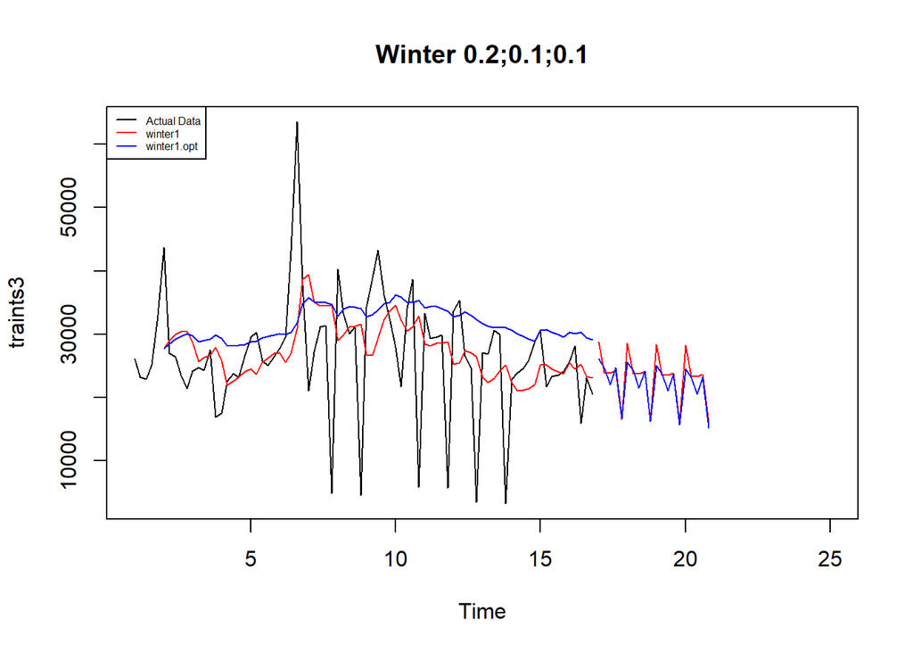

```r
plot(traints3,main="Winter 0.2;0.1;0.1",type="l",col="black",
     xlim=c(1,25),pch=12)
lines(xhat1,type="l",col="red")
lines(xhat1.opt,type="l",col="blue")
lines(forecast1,type="l",col="red")
lines(forecast1.opt,type="l",col="blue")
legend("topleft",c("Actual Data",expression(paste(winter1)),
                   expression(paste(winter1.opt))),cex=0.5,
       col=c("black","red","blue"),lty=1)
```

#### Akurasi Data Latih

```r
SSE1<-winter1$SSE
MSE1<-winter1$SSE/length(traints3)
RMSE1<-sqrt(MSE1)
akurasi1 <- matrix(c(SSE1,MSE1,RMSE1))
row.names(akurasi1)<- c("SSE", "MSE", "RMSE")
colnames(akurasi1) <- c("Akurasi")
akurasi1
```

```
##          Akurasi
## SSE  8.43520e+09
## MSE  1.05440e+08
## RMSE 1.02684e+04
```

```r
SSE1.opt<-winter1.opt$SSE
MSE1.opt<-winter1.opt$SSE/length(traints3)
RMSE1.opt<-sqrt(MSE1.opt)
akurasi1.opt <- matrix(c(SSE1.opt,MSE1.opt,RMSE1.opt))
row.names(akurasi1.opt)<- c("SSE1.opt", "MSE1.opt", "RMSE1.opt")
colnames(akurasi1.opt) <- c("Akurasi")
akurasi1.opt
```

```
##                Akurasi
## SSE1.opt  6.916439e+09
## MSE1.opt  8.645549e+07
## RMSE1.opt 9.298144e+03
```

```r
akurasi1.train = data.frame(Model_Winter.Latih = c("Winter 1","Winter1 optimal"),
                            Nilai_SSE=c(SSE1,SSE1.opt),
                            Nilai_MSE=c(MSE1,MSE1.opt),Nilai_RMSE=c(RMSE1,RMSE1.opt))
akurasi1.train
```

```
##   Model_Winter.Latih  Nilai_SSE Nilai_MSE Nilai_RMSE
## 1           Winter 1 8435199678 105439996  10268.398
## 2    Winter1 optimal 6916438840  86455485   9298.144
```

Berdasarkan nilai RMSE, metode Winter Aditif dengan parameter optimal menghasilkan nilai RMSE yang lebih kecil, sehingga dapat disimpulkan bahwa metode Winter Aditif Optimal lebih baik.

#### Akurasi Data Uji

```r
forecast1<-data.frame(forecast1)
ujits3df<-data.frame(ujits3)
selisih1<-forecast1-ujits3df
SSEtesting1<-sum(selisih1^2)
MSEtesting1<-SSEtesting1/length(ujits3df)
RMSEtesting1<-sqrt(MSEtesting1)


forecast1.opt<-data.frame(forecast1.opt)
selisih1.opt<-forecast1.opt-ujits3df
SSEtesting1.opt<-sum(selisih1.opt^2)
MSEtesting1.opt<-SSEtesting1.opt/length(ujits3df)
RMSEtesting1.opt<-sqrt(MSEtesting1.opt)


akurasi1.uji<-data.frame("Nilai RMSE Uji",RMSEtesting1,RMSEtesting1.opt)
akurasi1.uji
```

```
##   X.Nilai.RMSE.Uji. RMSEtesting1 RMSEtesting1.opt
## 1    Nilai RMSE Uji     26808.85         25251.44
```

### Winter Multiplikatif

#### Pemulusan

```r
winter2 <- HoltWinters(traints3,alpha=0.2,beta=0.1,gamma=0.3,seasonal = "multiplicative")
winter2$fitted
```

```
## Time Series:
## Start = c(2, 1)
## End = c(16, 5)
## Frequency = 5
##           xhat    level        trend    season
##  2.0 38769.765 27786.85  455.1371429 1.3727703
##  2.2 25236.532 28965.67  527.5051863 0.8556736
##  2.4 26873.950 29900.22  568.2092012 0.8820262
##  2.6 25684.844 30379.32  559.2990400 0.8301870
##  2.8 32775.091 30430.58  508.4949751 1.0593429
##  3.0 41118.537 28787.73  293.3598939 1.4139271
##  3.2 23253.258 26684.85   53.7359869 0.8696518
##  3.4 23871.587 27072.91   87.1687187 0.8789219
##  3.6 22262.929 27267.12   97.8730281 0.8135550
##  3.8 27844.119 28647.53  226.1267039 0.9643433
##  4.0 33578.494 26616.14    0.3747492 1.2615662
##  4.2 21031.620 24083.71 -252.9055662 0.8825392
##  4.4 21172.387 24192.80 -216.7059195 0.8830623
##  4.6 20928.353 24570.30 -157.2851409 0.8572620
##  4.8 21532.410 24961.19 -102.4676556 0.8661912
##  5.0 28698.701 26020.27   13.6865907 1.1023566
##  5.2 23559.018 26194.03   29.6941007 0.8983857
##  5.4 25357.343 27725.52  179.8741762 0.9086895
##  5.6 24799.260 27996.66  189.0006605 0.8798537
##  5.8 25941.647 28232.66  193.7000746 0.9125913
##  6.0 31911.603 28533.38  204.4026310 1.1104405
##  6.2 26904.177 27989.87  129.6106335 0.9567808
##  6.4 26316.660 28664.18  184.0812746 0.9122441
##  6.6 29168.051 32532.44  552.4988734 0.8816111
##  6.8 38685.151 40869.54 1330.9588595 0.9166989
##  7.0 46550.959 41999.09 1310.8180824 1.0748339
##  7.2 38574.918 38580.63  837.8899673 0.9785989
##  7.4 39053.487 37084.18  604.4558528 1.0362140
##  7.6 39653.716 36159.12  451.5050591 1.0831203
##  7.8 32248.741 35083.98  298.8402739 0.9114237
##  8.0 26651.334 29374.26 -302.0162185 0.9167279
##  8.2 28993.446 32052.33   -4.0070293 0.9046790
##  8.4 32556.369 33006.80   91.8403197 0.9836165
##  8.6 33501.697 32593.49   41.3253229 1.0265631
##  8.8 22134.625 32189.50   -3.2057322 0.6877033
```

[output cut: 25 more lines]

```
## 14.0 23478.325 21547.48 -580.9741839 1.1198017
## 14.2 21659.401 20871.61 -590.4638105 1.0679576
## 14.4 21930.343 20689.88 -549.5895491 1.0888789
## 14.6 21490.746 20642.95 -499.3239599 1.0668757
## 14.8  5757.885 20980.51 -415.6355931 0.2799864
## 15.0 42747.401 37141.48 1242.0245407 1.1136921
## 15.2 40678.528 36185.69 1022.2438487 1.0932755
## 15.4 38561.483 33733.69  674.8194806 1.1206960
## 15.6 35869.478 31682.98  402.2659399 1.1179431
## 15.8 12926.007 29882.72  182.0136223 0.4299392
## 16.0 37112.966 35244.07  699.9470112 1.0325214
## 16.2 32781.552 33734.09  478.9546724 0.9581594
## 16.4 33787.687 33237.94  381.4437174 1.0050062
## 16.6 30676.994 30075.98   27.1038771 1.0190647
## 16.8 14419.365 28630.56 -120.1486783 0.5057578
```

```r
xhat2 <- winter2$fitted[,2]

winter2.opt<- HoltWinters(traints3, alpha= NULL,  beta = NULL, gamma = NULL, seasonal = "multiplicative")
winter2.opt$fitted
```

```
## Time Series:
## Start = c(2, 1)
## End = c(16, 5)
## Frequency = 5
##           xhat    level      trend    season
##  2.0 38769.765 27786.85  455.13714 1.3727703
##  2.2 24666.194 28349.79  476.84350 0.8556736
##  2.4 25931.732 28907.13  493.05091 0.8820262
##  2.6 24835.480 29418.74  496.78662 0.8301870
##  2.8 32159.540 29870.32  487.68569 1.0593429
##  3.0 43228.977 30054.84  426.64297 1.4182045
##  3.2 26666.856 30081.26  346.05901 0.8764115
##  3.4 27220.934 30360.70  332.64415 0.8868677
##  3.6 25322.954 30596.63  313.17069 0.8192533
##  3.8 30263.020 30988.24  328.96538 0.9663384
##  4.0 39065.731 30907.03  246.37607 1.2539795
##  4.2 26466.859 30643.45  143.69628 0.8596725
##  4.4 26539.061 30654.14  116.91531 0.8624684
##  4.6 25767.285 30676.29   97.83601 0.8373034
##  4.8 26295.873 30685.56   80.00147 0.8547179
##  5.0 33089.237 30774.87   81.87632 1.0723502
##  5.2 25495.789 30759.27   62.25074 0.8272073
##  5.4 26094.815 30994.74   97.12698 0.8392811
##  5.6 25447.327 31080.40   94.81962 0.8162676
##  5.8 26780.867 31159.12   91.57623 0.8569687
##  6.0 32667.647 31238.49   89.12013 1.0427748
##  6.2 27106.052 31187.37   60.88164 0.8674423
##  6.4 26275.820 31330.82   77.50637 0.8365878
##  6.6 26170.859 32008.23  198.29729 0.8125949
##  6.8 29079.168 33574.56  473.74952 0.8540562
##  7.0 34954.373 34351.20  534.73762 1.0019616
##  7.2 30992.091 34475.02  451.99915 0.8873385
##  7.4 34275.093 34798.12  426.04486 0.9730562
##  7.6 39115.331 35127.84  406.64923 1.1007710
##  7.8 32820.382 35325.28  364.52664 0.9196009
##  8.0 31400.375 34784.17  182.17689 0.8980170
##  8.2 30488.083 35261.98  241.70113 0.8587303
##  8.4 34064.580 35602.24  261.54708 0.9498322
##  8.6 37558.965 35738.55  236.33104 1.0440330
##  8.8 25599.260 35793.88  199.88517 0.7112138
```

[output cut: 25 more lines]

```
## 14.0 26610.744 30002.21 -551.63985 0.9035732
## 14.2 25134.718 29329.76 -575.96368 0.8741355
## 14.4 25732.633 28709.74 -584.83515 0.9149412
## 14.6 25281.384 28090.20 -591.82205 0.9193771
## 14.8  7445.312 27520.21 -587.42675 0.2764405
## 15.0 25378.822 29251.96 -120.46173 0.8711814
## 15.2 25202.630 29306.95  -85.13577 0.8624596
## 15.4 26239.666 29100.36 -109.58891 0.9051040
## 15.6 26627.999 28893.65 -129.14544 0.9257243
## 15.8 13322.892 28665.70 -149.03965 0.4671968
## 16.0 26754.960 29201.37  -11.17349 0.9165735
## 16.2 24217.518 29156.03  -18.05192 0.8311323
## 16.4 25732.719 29277.52   10.04293 0.8786229
## 16.6 25951.195 28956.92  -56.53102 0.8979531
## 16.8 16163.630 28808.24  -75.08439 0.5625427
```

```r
xhat2.opt <- winter2.opt$fitted[,2]
```

#### Peramalan

```r
forecast2 <- predict(winter2, n.ahead = 20)
forecast2.opt <- predict(winter2.opt, n.ahead = 20)
```

#### Plot DW

[figure not shown]

```r
plot(traints3,main="Winter 0.2;0.1;0.1",type="l",col="black",
     xlim=c(1,25),pch=12)
lines(xhat2,type="l",col="red")
lines(xhat2.opt,type="l",col="blue")
lines(forecast2,type="l",col="red")
lines(forecast2.opt,type="l",col="blue")
legend("topleft",c("Actual Data",expression(paste(winter2)),
                   expression(paste(winter2.opt))),cex=0.5,
       col=c("black","red","blue"),lty=1)
```

#### Akurasi Data Latih

```r
SSE2<-winter2$SSE
MSE2<-winter2$SSE/length(traints3)
RMSE2<-sqrt(MSE2)
akurasi1 <- matrix(c(SSE2,MSE2,RMSE2))
row.names(akurasi1)<- c("SSE2", "MSE2", "RMSE2")
colnames(akurasi1) <- c("Akurasi lamda=0.2")
akurasi1
```

```
##       Akurasi lamda=0.2
## SSE2       8.749204e+09
## MSE2       1.093651e+08
## RMSE2      1.045777e+04
```

```r
SSE2.opt<-winter2.opt$SSE
MSE2.opt<-winter2.opt$SSE/length(traints3)
RMSE2.opt<-sqrt(MSE2.opt)
akurasi1.opt <- matrix(c(SSE2.opt,MSE2.opt,RMSE2.opt))
row.names(akurasi1.opt)<- c("SSE2.opt", "MSE2.opt", "RMSE2.opt")
colnames(akurasi1.opt) <- c("Akurasi")
akurasi1.opt
```

```
##                Akurasi
## SSE2.opt  6.908641e+09
## MSE2.opt  8.635801e+07
## RMSE2.opt 9.292901e+03
```

```r
akurasi2.train = data.frame(Model_Winter = c("Winter 2","winter2 optimal"),
                            Nilai_SSE=c(SSE2,SSE2.opt),
                            Nilai_MSE=c(MSE2,MSE2.opt),Nilai_RMSE=c(RMSE2,RMSE2.opt))
akurasi2.train
```

```
##      Model_Winter  Nilai_SSE Nilai_MSE Nilai_RMSE
## 1        Winter 2 8749204235 109365053  10457.775
## 2 winter2 optimal 6908640767  86358010   9292.901
```

Pada data latih, metode Winter Multiplikatif dengan parameter optimal menghasilkan nilai RMSE lebih kecil, sehingga dapat dikatakan bahwa metode Winter Multiplikatif adalah metode yang lebih baik.

#### Akurasi Data Uji

```r
forecast2<-data.frame(forecast2)
ujits3df<-data.frame(ujits3)
selisih2<-forecast2-ujits3df
SSEtesting2<-sum(selisih2^2)
MSEtesting2<-SSEtesting2/length(ujits3df)
RMSEtesting2<-sqrt(MSEtesting2)


forecast2.opt<-data.frame(forecast2.opt)
selisih2.opt<-forecast2.opt-ujits3df
SSEtesting2.opt<-sum(selisih2.opt^2)
MSEtesting2.opt<-SSEtesting2.opt/length(ujits3df)
RMSEtesting2.opt<-sqrt(MSEtesting2.opt)


akurasiwin2.uji<-data.frame("Nilai RMSE",RMSEtesting2,RMSEtesting2.opt)
akurasiwin2.uji
```

```
##   X.Nilai.RMSE. RMSEtesting2 RMSEtesting2.opt
## 1    Nilai RMSE     36099.67         25345.85
```

Pada data uji, metode Winter Multiplikatif dengan parameter optimal menghasilkan nilai RMSE lebih kecil, sehingga dapat disimpulkan bahwa metode Winter Multiplikatif merupakan metode yang lebih baik.

## Nilai Akurasi RMSE data latih metode SMA dan DMA

```r
akurasi_train.sma
```

```
##      Akurasi m = 4
## SSE   8.960772e+09
## MSE   1.179049e+08
## MAPE  6.551244e+01
```

```r
RMSE.dmalat<-sqrt(MSE_train.dma)
RMSE.dmalat
```

```
## [1] 13758.35
```

## Nilai Akurasi data uji metode SMA dan DMA

```r
RMSE.smauji<-sqrt(MSE_uji.sma)
RMSE.smauji
```

```
## [1] 5923.635
```

```r
RMSE.dmauji<-sqrt(MSE_test.dma)
RMSE.dmauji
```

```
## [1] 14799.28
```

## Nilai Akurasi SES dan DES

```r
accuracy(ramalanopt,test2$Jumlah)
```

```
##                      ME     RMSE      MAE       MPE     MAPE      MASE     ACF1
## Training set   658.5725 9424.135 6377.459 -33.85073 52.65036 0.8107900 0.141926
## Test set     -4236.9227 7282.752 5307.616 -32.27697 35.86079 0.6747769       NA
```

```r
accuracy(ramalandesopt,test2$Jumlah)
```

```
##                     ME      RMSE      MAE        MPE     MAPE      MASE
## Training set 1071.5242 10567.693 7371.936 -35.466737 60.87888 0.9372216
## Test set      362.3212  5958.374 4733.581  -8.901525 27.70679 0.6017977
##                   ACF1
## Training set 0.1260325
## Test set            NA
```

## Nilai Akurasi Winter aditif

```r
akurasi1.train
```

```
##   Model_Winter.Latih  Nilai_SSE Nilai_MSE Nilai_RMSE
## 1           Winter 1 8435199678 105439996  10268.398
## 2    Winter1 optimal 6916438840  86455485   9298.144
```

```r
akurasi1.uji
```

```
##   X.Nilai.RMSE.Uji. RMSEtesting1 RMSEtesting1.opt
## 1    Nilai RMSE Uji     26808.85         25251.44
```

## Nilai Akurasi Winter multiplikatif

```r
akurasi2.train
```

```
##      Model_Winter  Nilai_SSE Nilai_MSE Nilai_RMSE
## 1        Winter 2 8749204235 109365053  10457.775
## 2 winter2 optimal 6908640767  86358010   9292.901
```

```r
akurasiwin2.uji
```

```
##   X.Nilai.RMSE. RMSEtesting2 RMSEtesting2.opt
## 1    Nilai RMSE     36099.67         25345.85
```

# Kesimpulan

Metode yang tepat digunakan adalah metode Winter, karena plot awal data menggambarkan bentuk musiman. Secara umum, data yang digunakan memiliki puncak(atas dan bawah) yang relatif sama sehingga lebih tepat menggunakan metode Winter Aditif. Selanjutnya nilai akurasi metode Winter Aditif pada data uji menghasilkan RMSE sebesar 26808.85 untuk parameter alpha=0.2, beta=0.1, gamma=0.1. Sedangkan jika menggunakan parameter optimal menghasilkan nilai RMSE sebesar 25251.44.